# MIT further

Min

2025-03-29

# The MIT data analysis

The parameters $\alpha_i(t)$s and $\beta_i(t)$s in our model represent intrinsic social personality traits—social initiative and social receptiveness, respectively—that persist beyond environmental confounders. By explicitly adjusting for institutional factors (academic year cohort) and spatial determinants (floor proximity) within the Cox proportional hazards framework, we isolate these latent behavioral constructs from transient contextual influences.

Our analysis reveals substantial heterogeneity in social behavioral signatures. Both Inter-individual divergence (individual-varying) and Intra-individual evolution (time-varying).

### The overall $\alpha_i$ and $\beta_i$ for all individuals

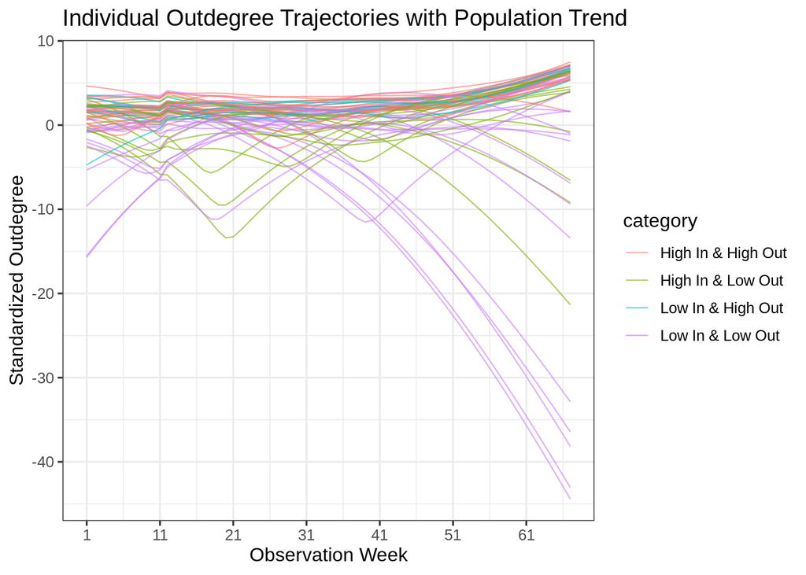

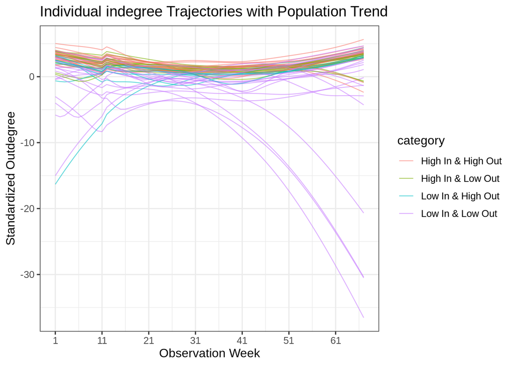

### Top 4 individuals with the highest cumulative indegree/outdegree

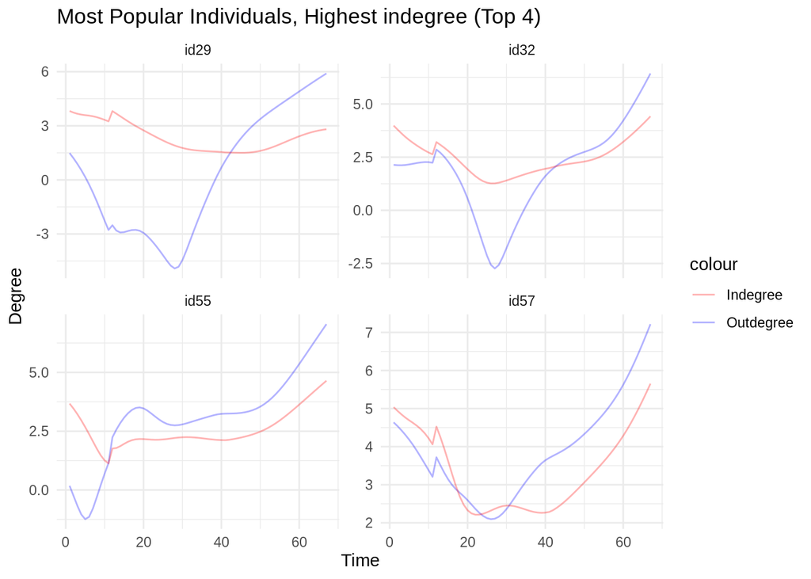

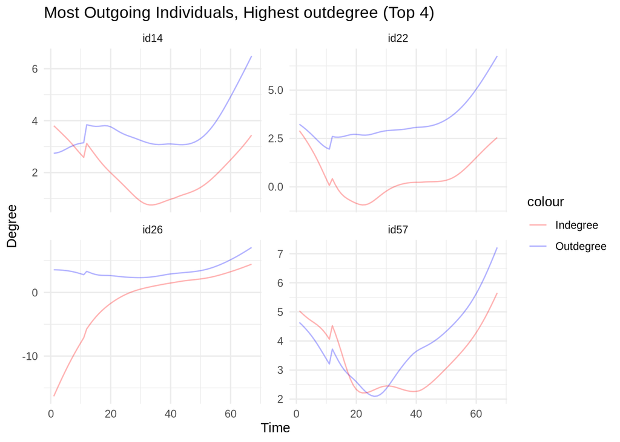

### Top 4 individuals with the highest volatility in indegree/outdegree

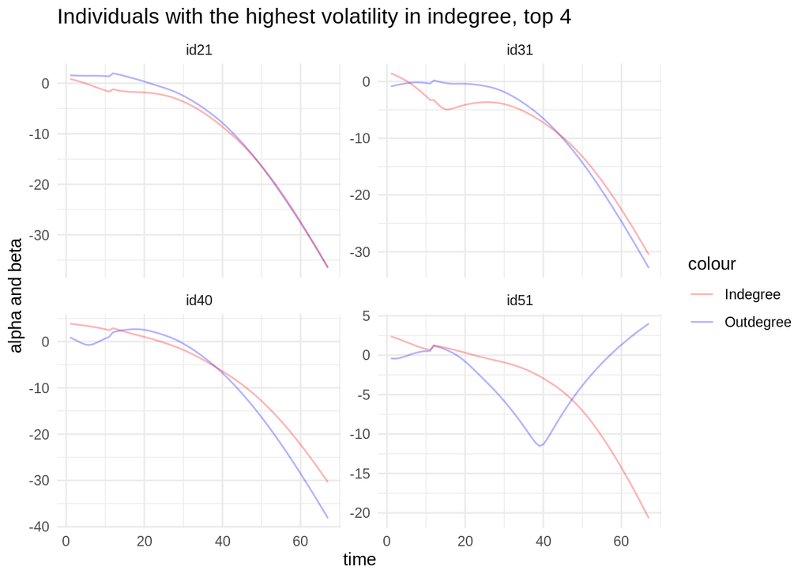

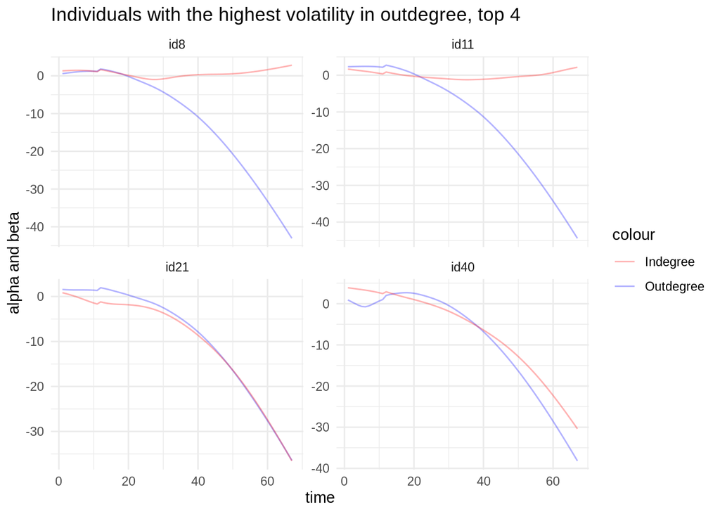

### Group Changes

To evalue the time volatility of $\alpha$ and $\beta$

We first Divide the observation period into 5 equal intervals: $T_1,...T_5$.

- High In & High Out (Social Hubs)
- High In & Low Out (Passive Influencers)
- Low In & High Out (Social Catalysts)
- Low In & Low Out (Peripheral Observers)

Compute the proportion of individuals shifting between categories across intervals. Use alluvial diagrams to illustrate the transitions

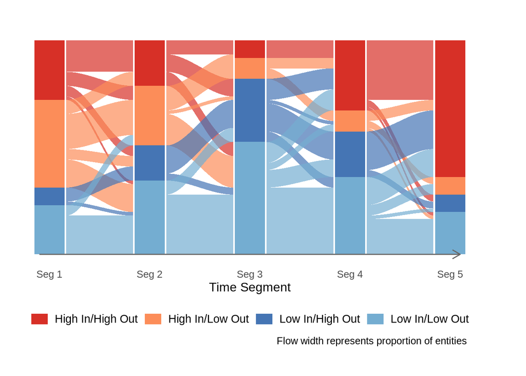

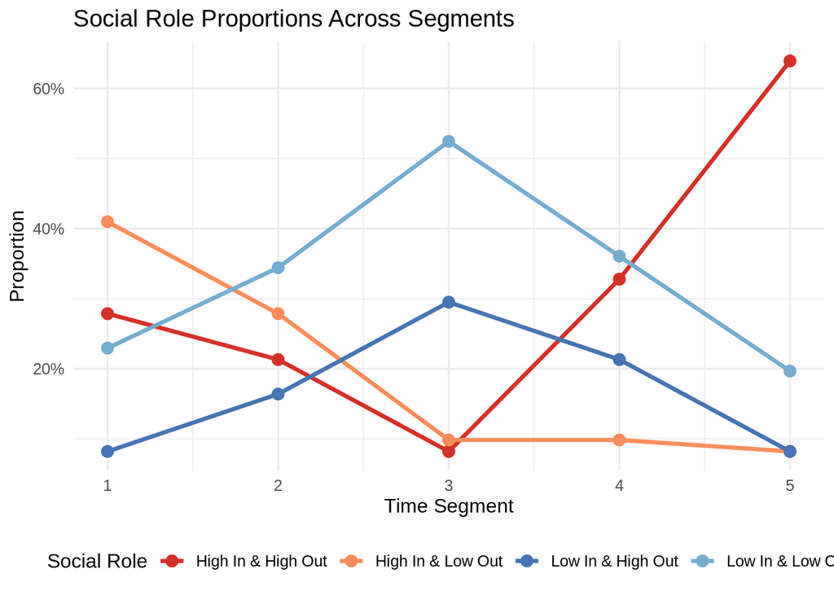

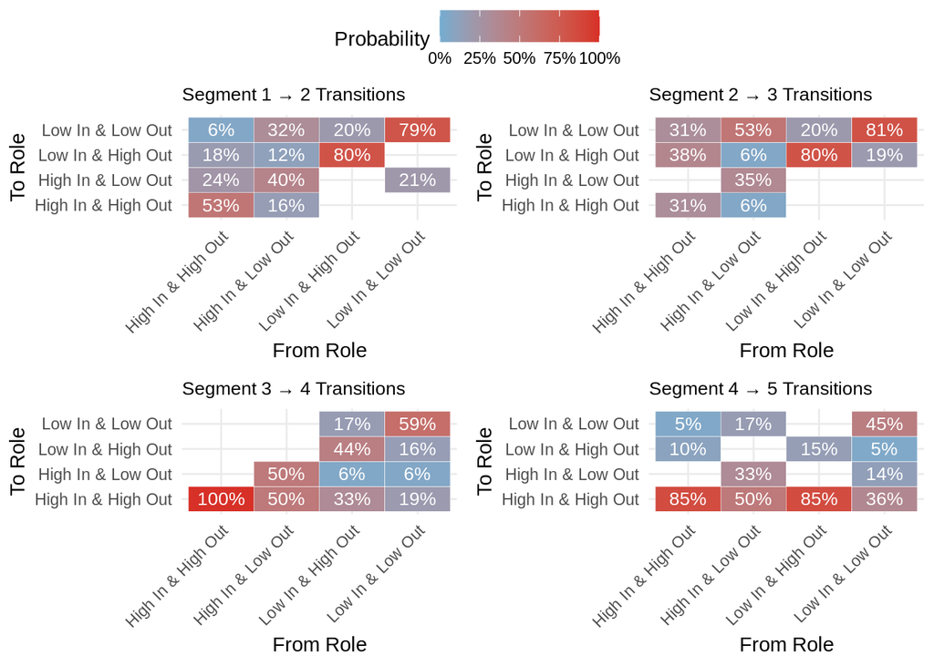

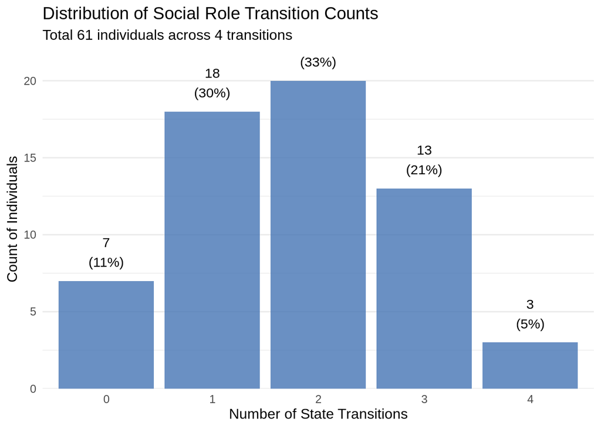

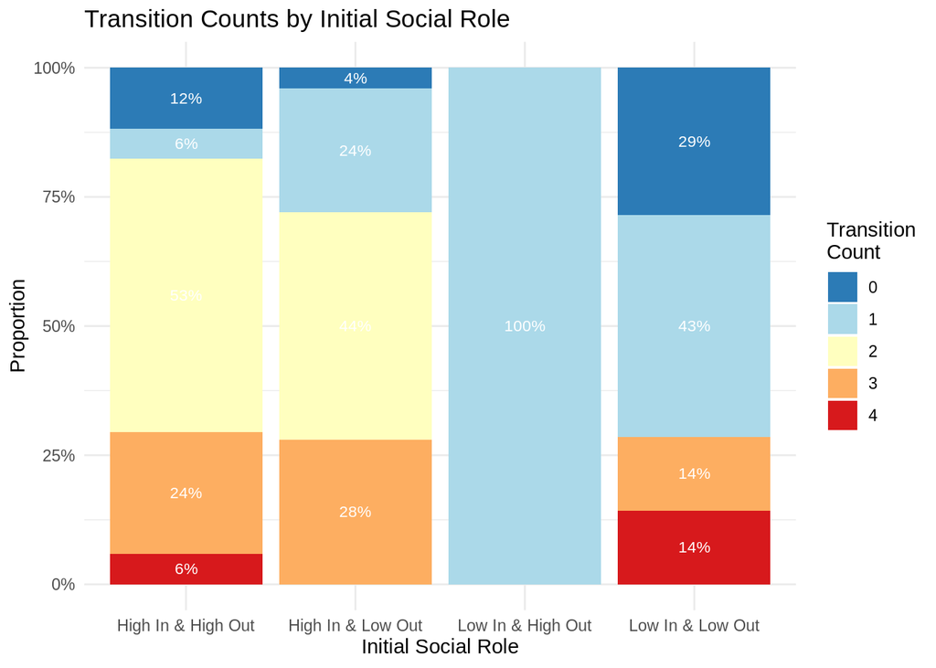

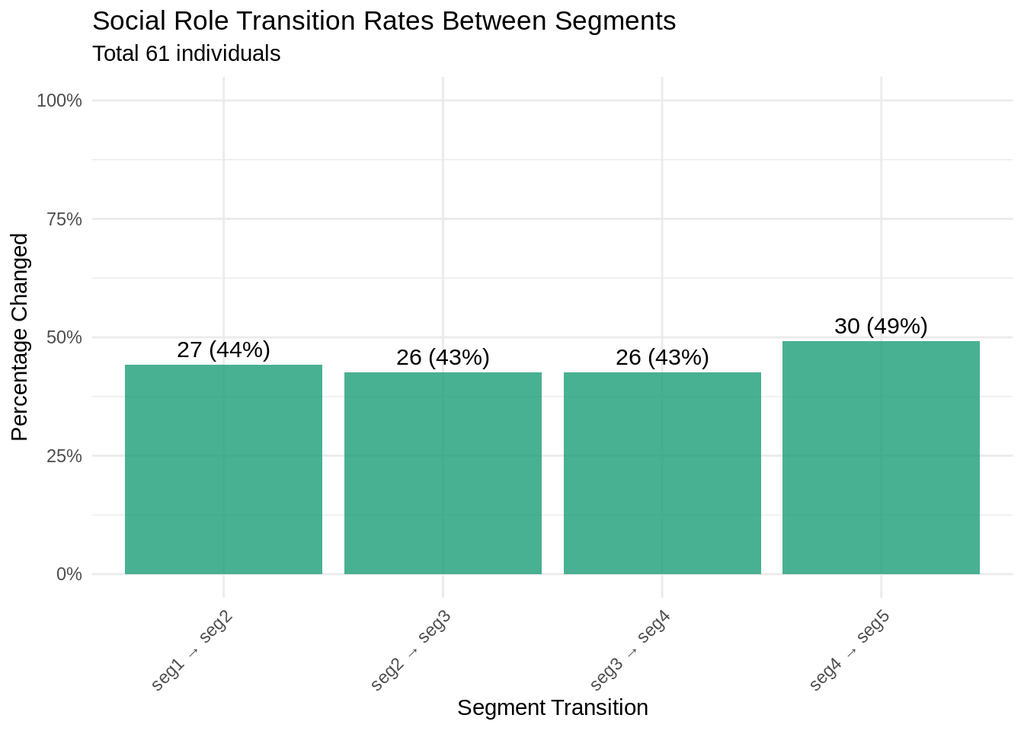

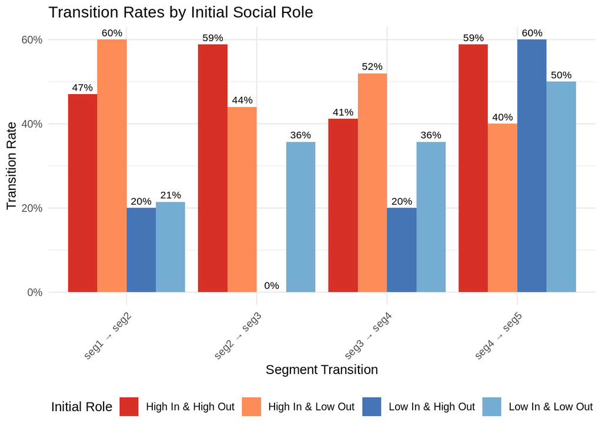